# A4: Incarceration Trends

Kevin Baron

2022-11-21

## Abstract

One of the sharpest manifestations of racism in the United States is its prison system, a complex set of social and political structures. This site **exposes the patterns of inequality** using incarceration data collected by the [Vera Institute](https://www.vera.org/).

(Abstract material included from [Canvas Assignment Overview](https://canvas.uw.edu/courses/1616427/assignments/7569461#:~:text=learn%20from%20it%3F%3E-,Overview,-One%20of%20the))

## Introduction

Incarceration in the United States represents a highly intersectional problem. It involves a complex set of social and political structures, including the [over-policing](https://www.pewresearch.org/fact-tank/2020/06/03/10-things-we-know-about-race-and-policing-in-the-u-s/). of individuals of color and the [war on drugs](https://drugpolicy.org/issues/race-and-drug-war), which have led to the disproportionate incarceration of people of color. These issues are *very* well summarized in the documentary **[13th](https://www.youtube.com/watch?v=krfcq5pF8u8)**.

(Introductory material included from [Canvas Assignment Overview](https://canvas.uw.edu/courses/1616427/assignments/7569461#:~:text=learn%20from%20it%3F%3E-,Overview,-One%20of%20the))

The people, families, and neighborhoods that are implicated by or otherwise connected with this data are the direct stakeholders of the dataset. Less direct stakeholders would be the prisons, which could use comprehensive data to better understand how their respective counties and states compare to others, and the counties and states themselves, which could similarly utilize the comprehensive data to better understand how they fit into the larger subset and adjust policies and propose referendums accordingly.

Because of this set of stakeholders, the values of civil justice, equality, and transparency must be held central and engaged throughout the process of data analysis.

Questions addressed through the report include the following:

1. How has the US prison population changed from 1970 to 2018?
2. How have each of the states’ prison populations changed from 1970 to 2018?
3. How does disproportionality of incarceration of Black people vary with county population for all US counties?
4. Where are the counties with the most disproportional Black incarceration rates located across the country?

## Growth of the U.S. Prison Population

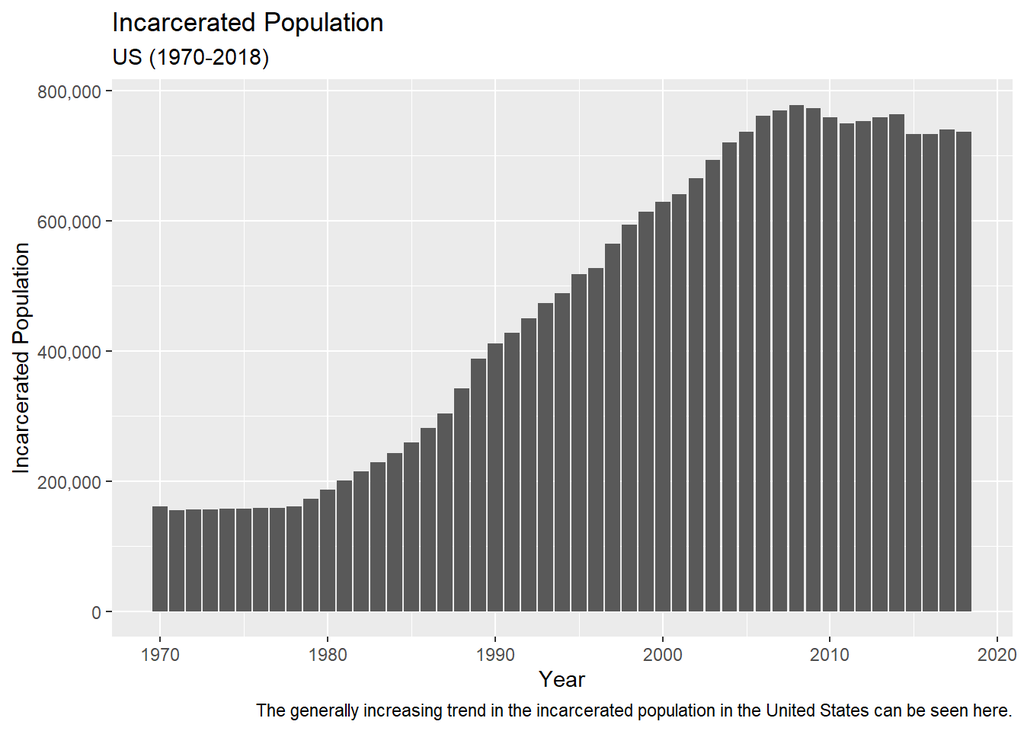

This plot shows that the total incarcerated population in the United States was fairly static through the 1970s. It steadily increased from circa 1980 to circa 2005, and has plateaued with a slightly declining trend from circa 2005 to 2018. The increasing trend could reflect a few decades of prison construction, crackdowns on crime, and general population growth, while the plateau could signify having reached near maximum capacity in prisons with a reduction in planning for overflow or new prison construction.

## Growth of Prison Population by State

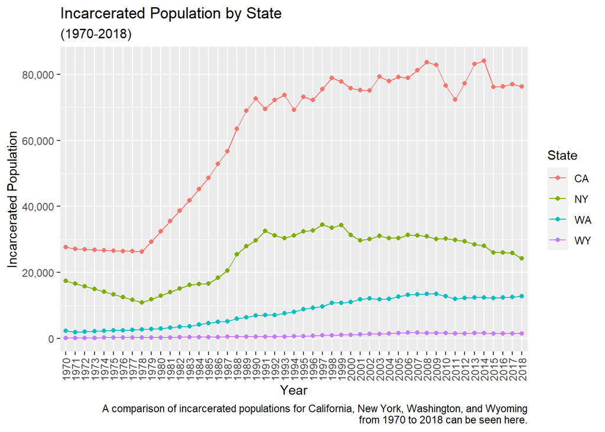

This plot shows the trends of total incarcerated populations for multiple states from 1970 to 2018. The states included are California, New York, Washington, and Wyoming. California is included because it had the largest incarcerated population in 2018. New York is included because it has the largest urban popluation in the country in New York City. Washington is included to give local perspective. Wyoming is included because it has the smallest general population, and this could provide some added perspective to the states with higher incarcerated populations counts. It can be seen that both California and New York both show a distinct turn from downward trends to upward trends, bouncing on the year 1978, while Washington shows more steady growth throughout the period.

## Disproportionality of Black Incarceration by County Population (2018)

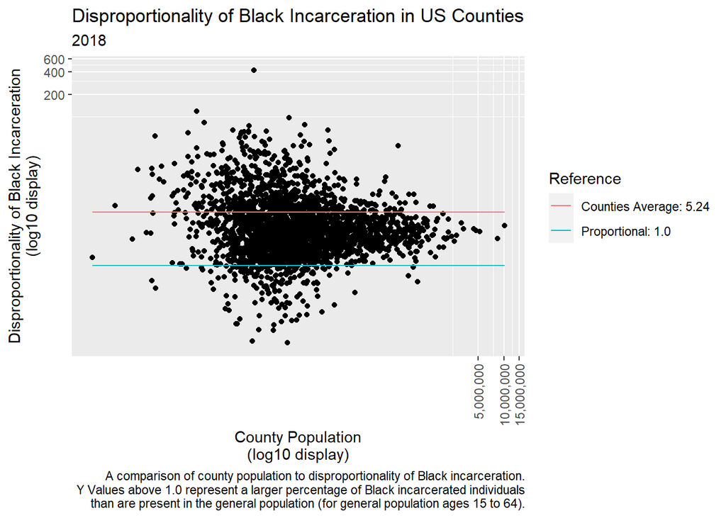

Question #3) How does disproportionality of incarceration of Black people vary with county population for all US counties?

It can be seen from this scatter plot that most counties have Black incarcerated populations that are larger relative to the entire incarcerated population than the Black populations aged 15 to 64 compared to the general populations of the same age. (While data for total population of all ages for each county was available, data for Black populations of all ages was not, so the 15 to 64 age category, where both data sets were available, was used. This is a wide enough age range to capture meaningful data trends). Counties with populations in the middle two quartiles are more likely to have a wide range of Black incarceration disproportionality, with some counties showing less representation of Black people in prisons than in the general population (Y values less than 1.0), and some showing over 100 times more Black representation in prisons than in the general population. As county population increases, the range of Y values narrows and converges, but not on the proportional value of 1.0. Instead, they converge on a value between 1.0 and the average disproportionality of 5.24.

## Disproportionality of Black Incarceration by US County (2018)

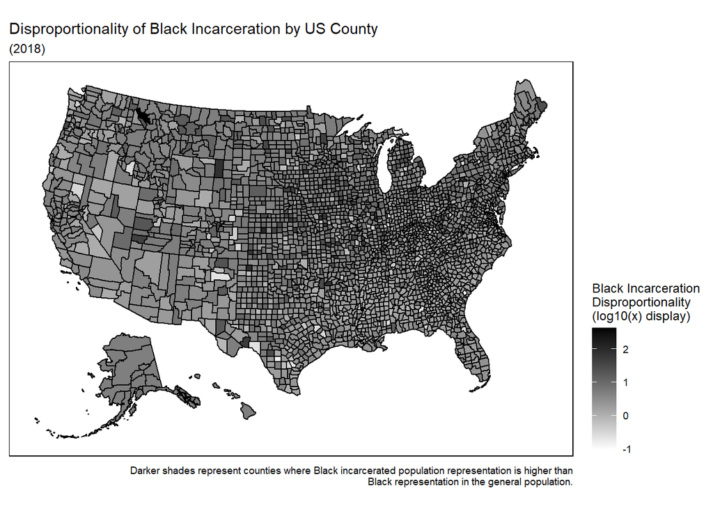

Question #4) Where are the counties with the most disproportional Black incarceration rates located across the country?